# Copilot Consumption and Ways of Working

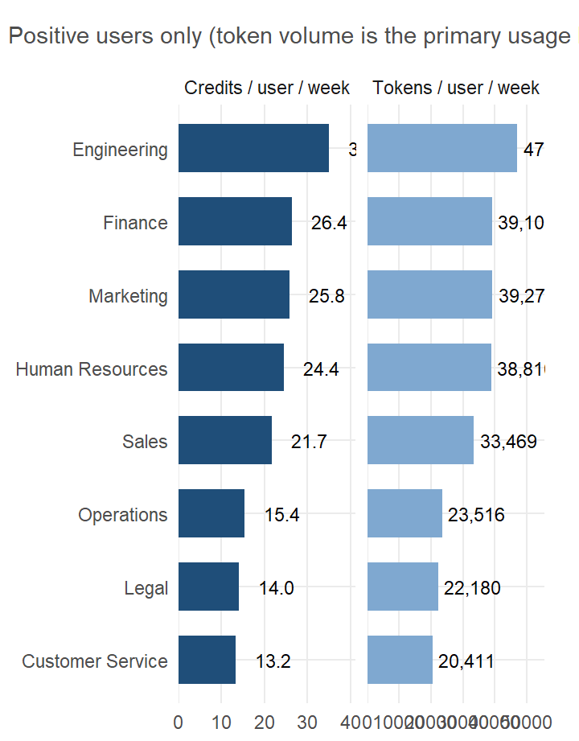

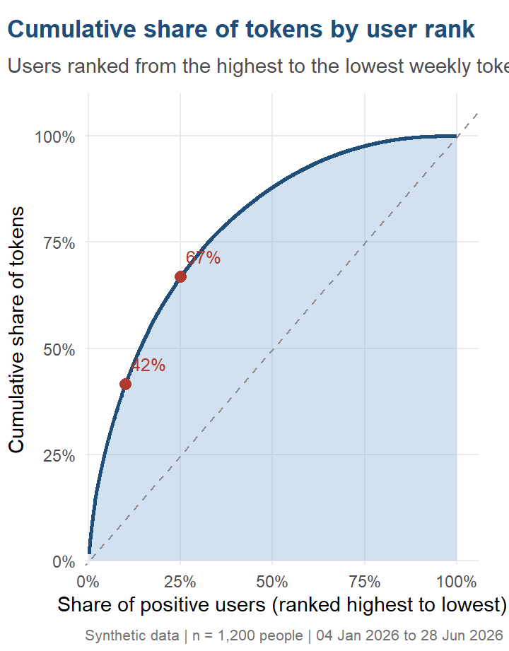

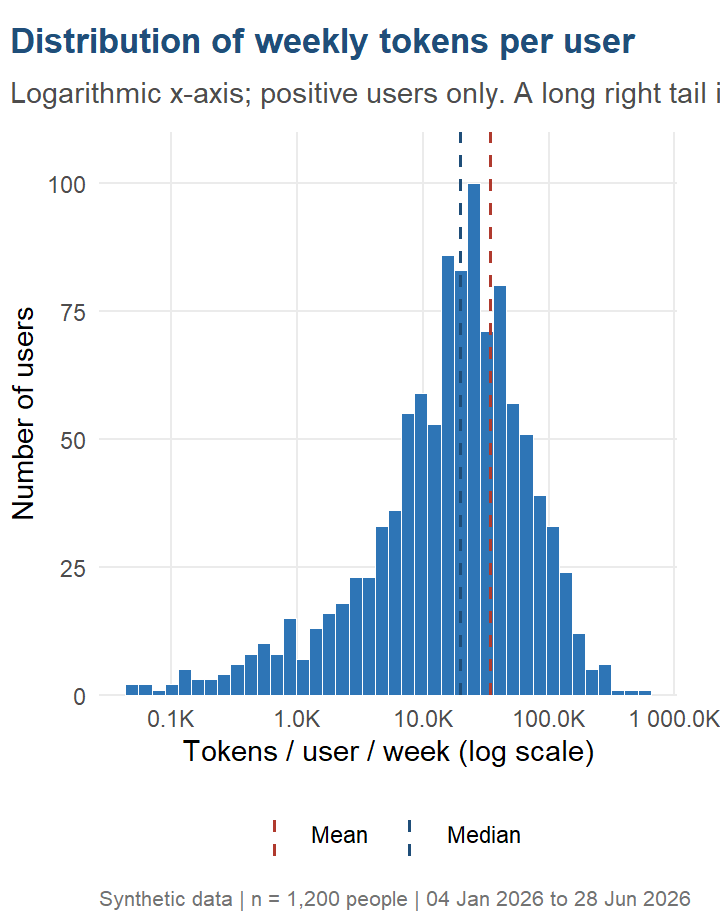

[figure not shown]

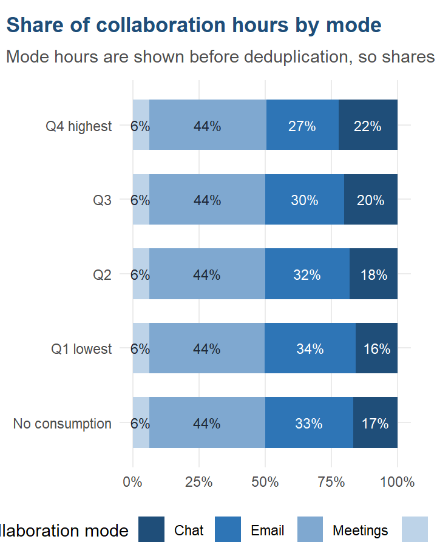

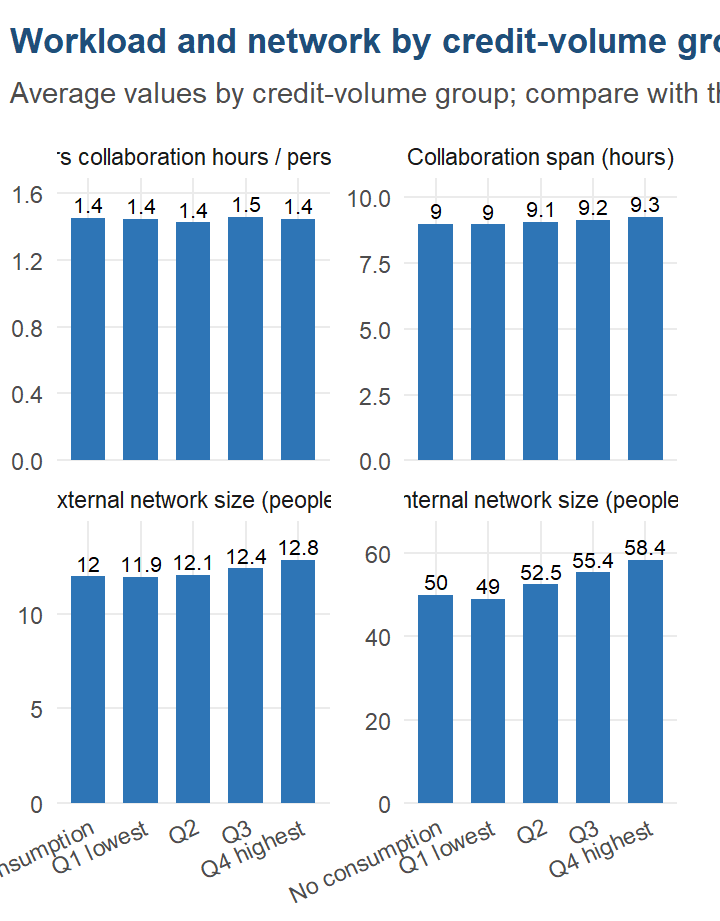

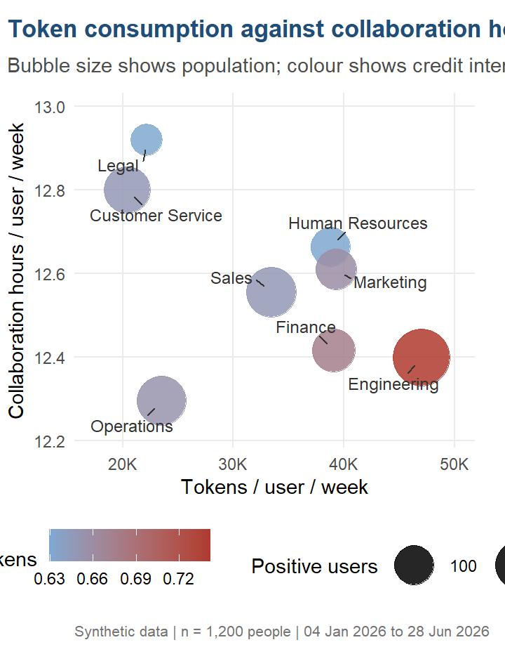

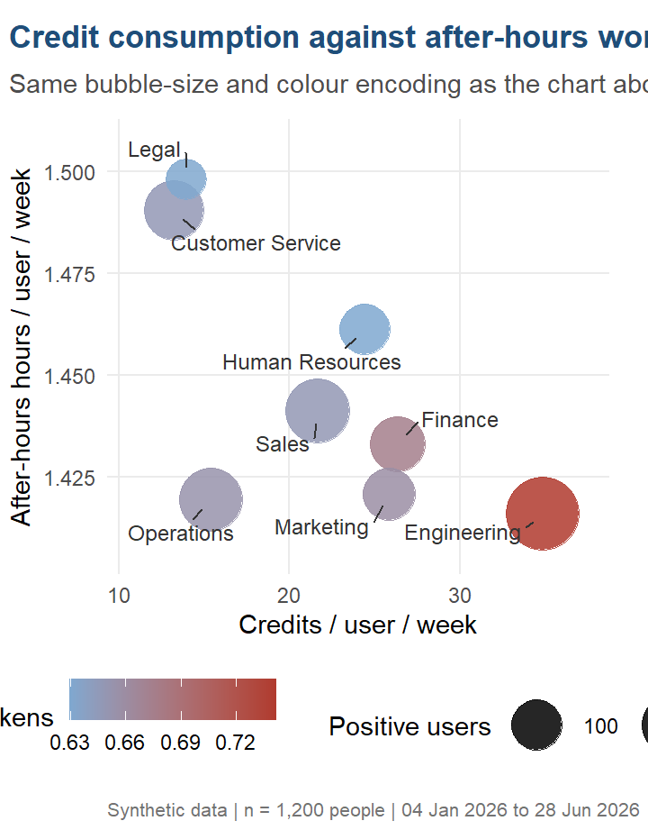

[figure not shown]

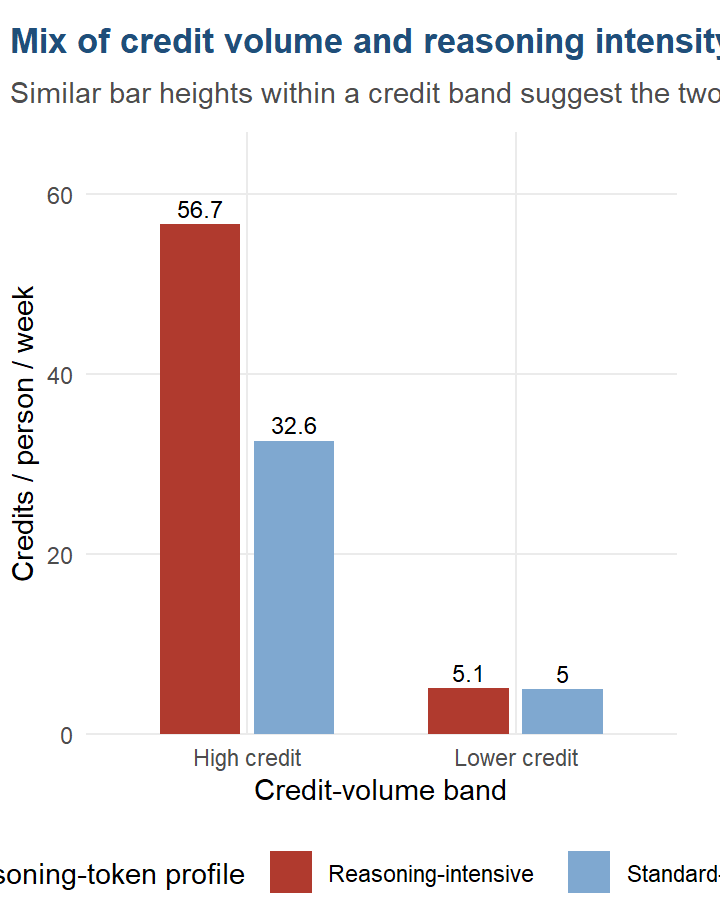

[figure not shown]

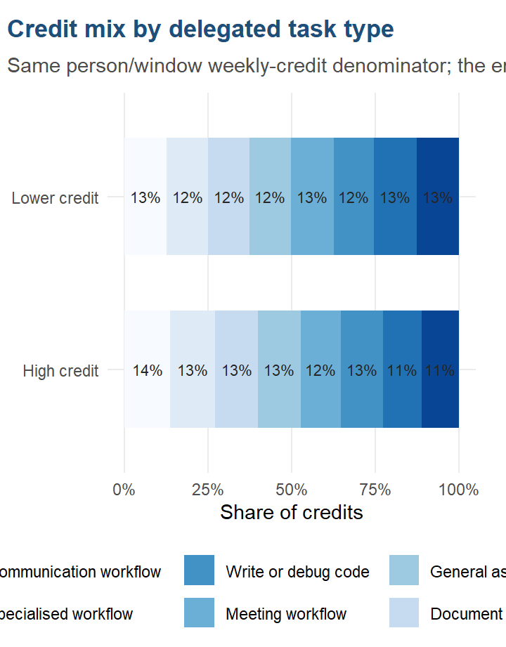

[1 more figures not shown]

# Overview

Synthetic demonstration Higher-credit users lean more towards chat and less towards email, while function and seniority explain more of total collaboration volume.

### People represented

1,200

### Positive users

87.9%

### Credits per person per week

20.2

### Credits per 1,000 tokens

0.68

### Consumption baselines by function

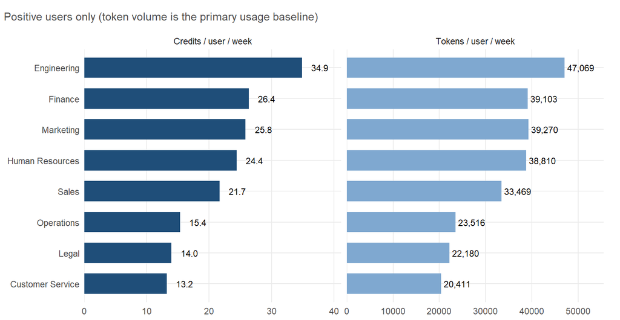

### Baseline table

Function baseline (credit intensity is credits per 1,000 tokens; lower means a less expensive token mix).

| Function | People | Credits / user / week | Actions / user / week | Tokens / user / week | Credits / 1,000 tokens | Reasoning share |
| --- | --- | --- | --- | --- | --- | --- |
| Engineering | 209 | 34.9 | 18.6 | 47,069 | 0.74 | 16.8% |
| Finance | 119 | 26.4 | 13.4 | 39,103 | 0.67 | 13.6% |
| Marketing | 106 | 25.8 | 17.1 | 39,270 | 0.66 | 12.8% |
| Human Resources | 100 | 24.4 | 13.0 | 38,810 | 0.63 | 11.4% |
| Sales | 162 | 21.7 | 14.0 | 33,469 | 0.65 | 12.4% |
| Operations | 156 | 15.4 | 10.8 | 23,516 | 0.65 | 12.5% |
| Legal | 64 | 14.0 | 10.0 | 22,180 | 0.63 | 11.5% |
| Customer Service | 139 | 13.2 | 8.1 | 20,411 | 0.65 | 12.3% |

### Population-level highlights

**Consumption volume and consumption mix are separate.** The highest-credit people are not automatically the most reasoning-intensive, and the standard Power User definition is based on sustained actions rather than credit cost.

**The clearest Ways of Working difference is channel mix.** Higher-credit users lean more towards chat and less towards email. Total collaboration volume is more sensitive to function and seniority than to consumption itself.

**Reasoning-intensive use carries a weak workload signal in this simulation.** Within the same broad credit band, reasoning-intensive users have slightly more after-hours collaboration and a longer collaboration span. This is an association to investigate rather than evidence of harm.

### How to read credit intensity

**Credit intensity** is the number of credits consumed per 1,000 tokens. It is a cost-mix measure rather than a productivity or value measure. Lower intensity means the observed token mix consumes fewer credits. It does not establish that the work was more efficient, because the report does not observe output quality, task difficulty or business value.

# Token distribution

### Concentration of token consumption across users

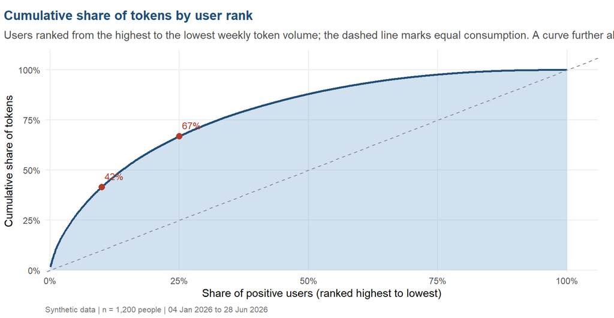

### Concentration bands

Users ranked by average weekly tokens, positive users only (n = 1,055).

| Band | People | Share of users | Share of tokens |
| --- | --- | --- | --- |
| Top 1% | 10 | 1% | 9% |
| Next 4% (top 1-5%) | 42 | 4% | 18% |
| Next 5% (top 5-10%) | 53 | 5% | 14% |
| Next 15% (top 10-25%) | 158 | 15% | 25% |
| Next 25% (top 25-50%) | 264 | 25% | 21% |
| Bottom 50% | 528 | 50% | 12% |

### Shape of the token-volume distribution

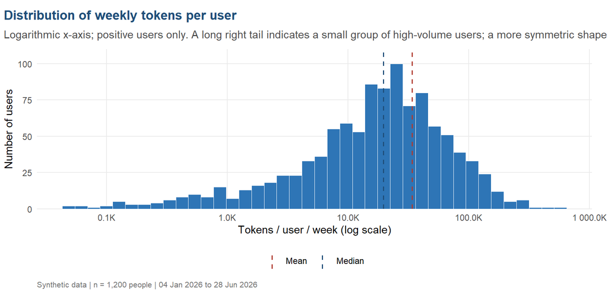

### Why a concentration curve and a log histogram?

Token and credit consumption in Copilot data is typically **right-skewed**: most people use a modest, fairly similar amount, while a small group of heavy users account for a disproportionate share of total volume. A boxplot or violin plot would compress this shape into a small number of summary points and understate how concentrated the top tail is.

The concentration curve above answers the practical question directly: **what share of tokens does the top share of users account for?** The histogram (log scale) shows the shape that produces that concentration, and the gap between the median and mean lines is itself evidence of the right skew.

This has a practical implication for interpreting averages elsewhere in this report. A mean such as “credits per person per week” can be pulled upward by a small number of heavy users, so organisational and segment comparisons should be read alongside this distribution rather than in isolation.

# Credit relationships

### Ways of Working metrics by credit-consumption group

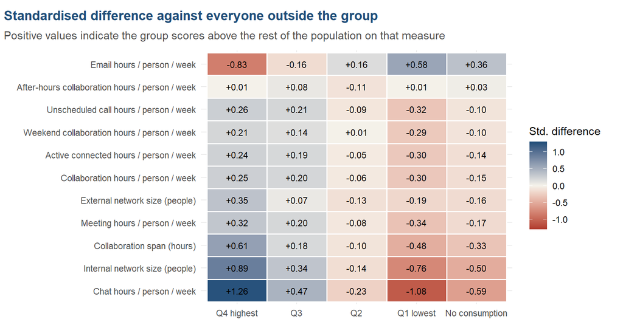

### Credit groups

Credit-volume groups (quartiles are calculated among positive users).

| CreditQuartile | People | Credits / person / week | Share of population |
| --- | --- | --- | --- |
| No consumption | 145 | 0.0 | 12.1% |
| Q1 lowest | 264 | 1.8 | 22.0% |
| Q2 | 264 | 7.7 | 22.0% |
| Q3 | 264 | 17.8 | 22.0% |
| Q4 highest | 263 | 64.8 | 21.9% |

### Collaboration mode mix by credit-consumption group

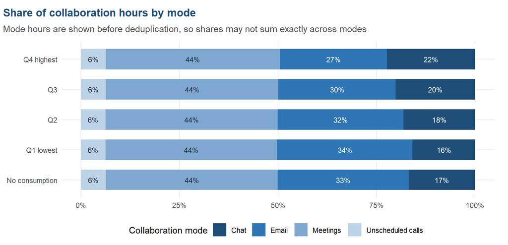

### Workload and network

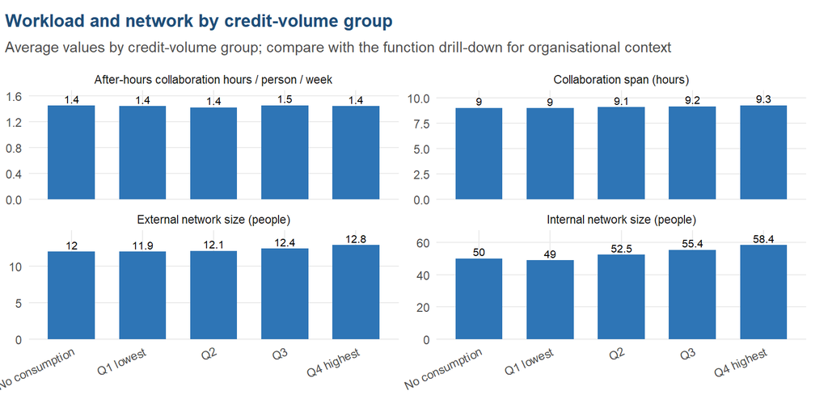

# Function drill-down

### Consumption and collaboration volume by function

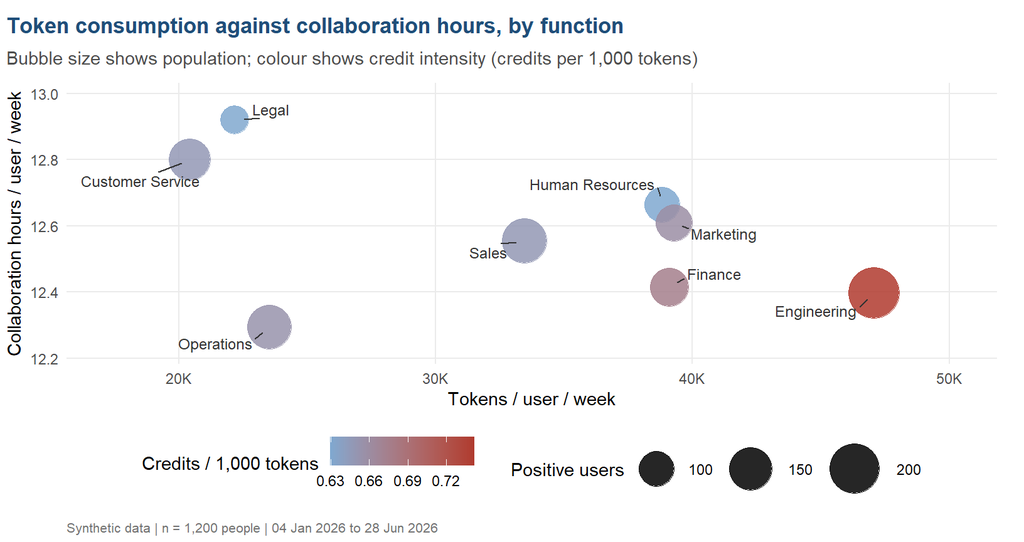

### Reading the chart

The colour adds a third dimension. A darker point consumes more credits for the same number of tokens. This can indicate a more expensive reasoning mix, but it may also reflect harder work. The appropriate follow-up is to examine task mix and value, rather than treating lower intensity as automatically better.

### Workload and credit intensity by function

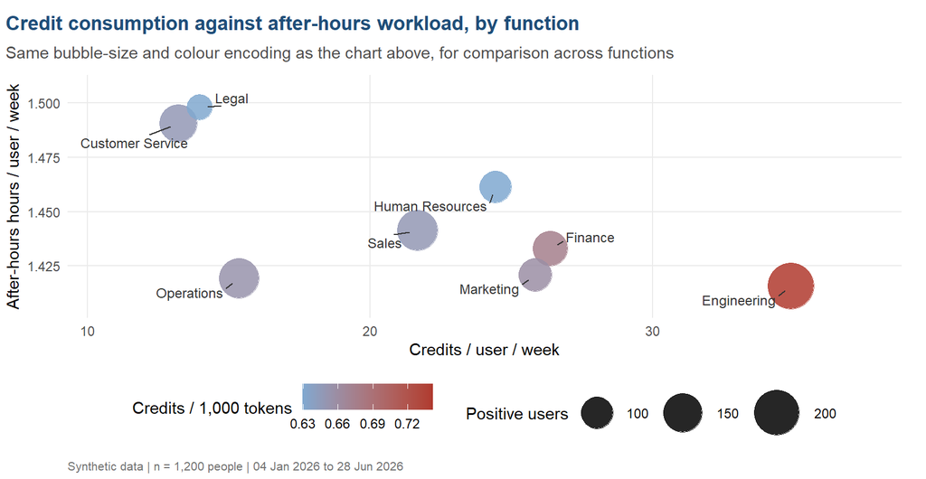

### Function comparison matrix

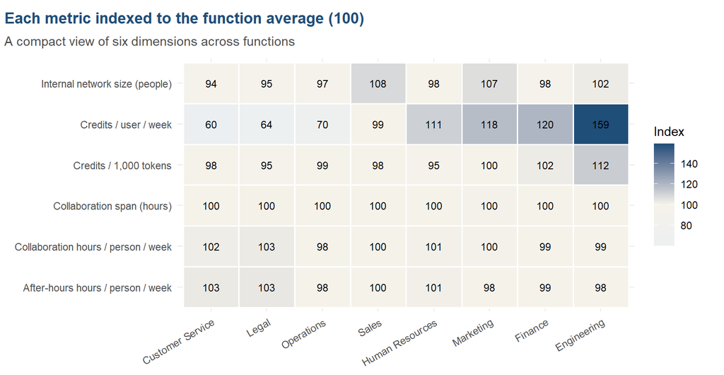

# Consumption mix

### Credit volume by credit band and reasoning-token profile

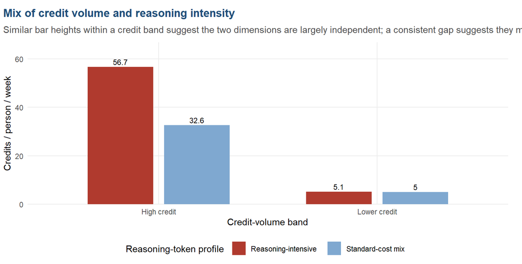

### Profile definitions

| Profile component | Definition | Interpretation |
| --- | --- | --- |
| High credit | Q3 or Q4 among positive users | Higher total credit volume |
| Lower credit | Q1 or Q2 among positive users | Lower total credit volume |
| Reasoning-intensive | Upper quartile of reasoning-token share among people with at least 10,000 tokens | More expensive token mix |
| Standard-cost mix | At least 10,000 tokens and below the reasoning-intensive threshold | Less expensive observed token mix |
| Insufficient token volume | Positive credits but insufficient observed tokens to classify | Unclassified; excluded from measured-profile comparisons |

The label **reasoning-intensive** describes the measurable consumption pattern without assuming recklessness. Business value and task difficulty are needed before judging whether the additional expense was warranted. Unclassified consumers remain in population and credit-volume denominators. They are never silently included in the standard-cost group.

Classification coverage, including unclassified consumers.

| ReasoningProfile | People |
| --- | --- |
| Insufficient token volume | 29 |
| No consumption | 145 |
| Reasoning-intensive | 257 |
| Standard-cost mix | 769 |

### Workload by reasoning-token profile within credit bands

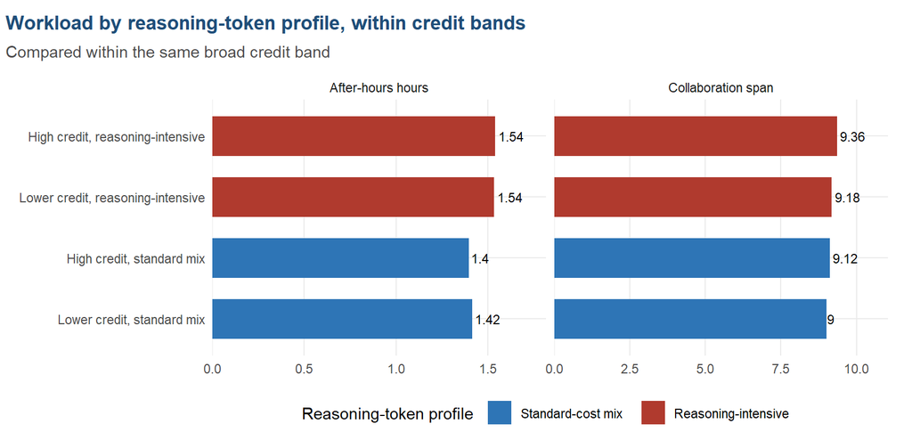

### What work consumes the credits?

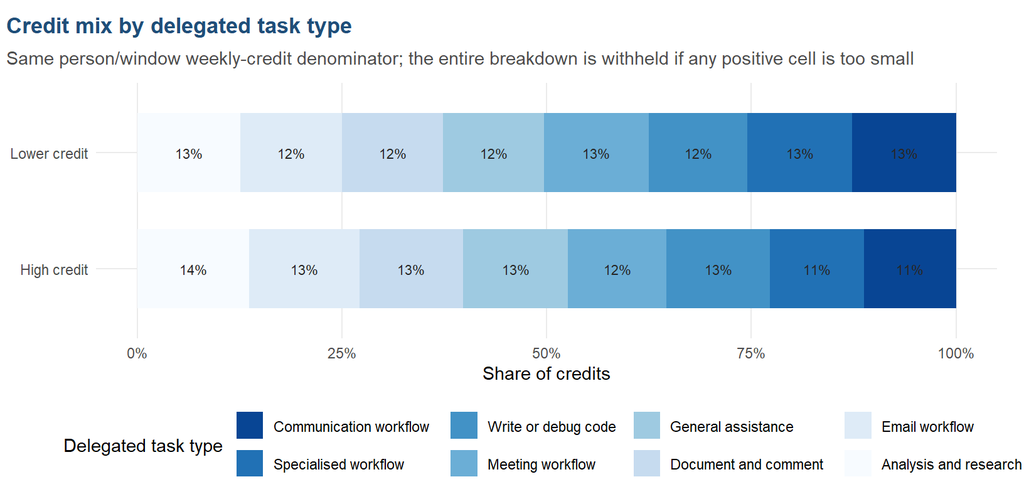

# Usage segments

### Credit-volume distribution within usage segments

```
Credit-volume breakdown withheld: at least one positive cell is below the disclosure floor. No residual shares are published.
```

### Why keep both?

The standard usage ladder answers an adoption question: is activity frequent and sustained? Credit volume answers a resource-consumption question: how much credit is used? A Power User can have a standard-cost token mix and moderate credit volume, while someone with fewer actions can consume more credit through longer or more reasoning-intensive requests.

The report therefore keeps usage segments as a useful supporting view without letting them substitute for the unique information in the consumption query.

### Segment baseline

Latest-week baseline (28 Jun 2026); segment classification uses the trailing 12 weeks.

| Segment | People | Weekly actions | Credits / person / week | Tokens / person / week | Credit intensity |
| --- | --- | --- | --- | --- | --- |
| Power User | 424 | 37.37 | 64.12 | 92,867 | 0.69 |
| Habitual User | 293 | 12.60 | 21.10 | 33,449 | 0.63 |
| Novice User | 261 | 5.10 | 7.52 | 12,656 | 0.59 |
| Low User | 49 | 0.88 | 0.71 | 1,480 | 0.48 |
| Non-user | 173 | 0.00 | 0.00 | 0 | N/A |

### Interpretation guardrail

Neither segment nor credit group is a performance category. They describe observed use. The table and chart align activity to the latest observation week, while the segment reflects sustained behaviour over its trailing 12-week window. Results should be reported for privacy-safe cohorts and interpreted alongside role, task mix, entitlement and organisational context.

# Methods and appendix

### Join and aggregation workflow

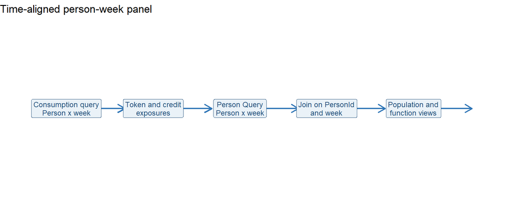

### Core rules

| Question | Rule |
| --- | --- |
| Organisational attributes | Use a disclosed Person Query snapshot when exact date matching is unnecessarily restrictive |
| Weekly relationships | Aggregate consumption to person-week, then join on `PersonId` and weekly `MetricDate` |
| Credit quartiles | Calculate among positive users and retain non-users separately |
| Reasoning profile | Require sufficient token volume before classifying the token mix |
| Network measures | Treat internal and external network size as stock measures; never sum them across weeks |
| Privacy | Withhold the entire segment/task cross-tab if any positive cell is below the approved minimum; never publish reconstructable residuals |
| Task allocation | Validate unique person/task/window keys and reconcile to each person’s full-window weekly credits before plotting; fail on mismatch |

### Simulation design

This dashboard is a demonstration of analytical possibilities. Every person, token, credit and Ways of Working value is synthetic.

The simulation creates 1,200 people across eight functions and 26 weeks. Function and level affect both AI appetite and some Ways of Working measures so that raw associations contain realistic compositional confounding. Credit consumption is derived from input, output and reasoning tokens using synthetic relative weights. Reasoning tokens have the highest weight, which makes credit intensity responsive to token mix rather than merely to volume.

The following effects are deliberately modest:

- Higher consumption is associated with more chat and less email as a share of collaboration modes.
- Total collaboration volume is raised mainly by organisational composition.
- Internal network size has a small residual association after composition is considered.
- Reasoning-intensive use has a weak positive association with after-hours collaboration and collaboration span.
- External network size is a null.

### Synthetic source assets

The uncompressed source-shaped CSVs sit under:

```
_data/consumption/
  consumption-query/
  person-query/
  reference/
```

They are intended for demonstrations, workshops and adaptation of the template. They contain no customer data or real identifiers. The task allocation is generated locally from the same-window weekly credit totals by `generate-demo-data.R`; it is not an independently measured task feed. See the topic README for fixture provenance, generator seed and the inclusive observation-window contract.

### Definitions and limitations

**Credit intensity** means credits consumed per 1,000 tokens. It is preferred over “token cost-efficiency” because the report observes resource consumption rather than the quality or value of the output.

**Reasoning-intensive** means the upper quartile of reasoning-token share among people with at least 10,000 observed tokens. It is preferred over “reckless” because expensive reasoning can be appropriate for a difficult task.

The example Consumption export that motivated this template did not expose input, output and reasoning-token fields. A real implementation can only reproduce the reasoning profile when those governed token fields and applicable credit weights are available. If they are absent, omit the profile rather than inferring it from total credits.

The dashboard shows associations. It does not establish that AI consumption caused a working pattern, and it does not observe output quality, task difficulty or business value.

### Replacing the synthetic data

1. Replace the CSVs in `_data/consumption` with schema-aligned governed exports.
2. Validate the identity crosswalk and disclose the match rate.
3. Confirm whether missing consumption rows mean zero activity, suppression or ineligibility.
4. Recompute credit weights from the applicable governed rate card.
5. Keep person-level averaging so each person carries equal analytical weight.
6. Retain the privacy threshold and the organisational composition checks.
7. Reconcile task-feed coverage, dates and person totals before interpreting task shares. A mismatch stops this example; do not rescale the feed to conceal it.

This synthetic demonstration is not a disclosure certification for tenant data. In particular, concentration curves and distribution plots require an approved release policy beyond subgroup-count checks before any real-data publication.